# Preliminary Network Visualization with R

## Some other useful {igraph} functions

Other functions from {igraph} can be run to show alternative representations of the graph properties or to return graph properties…

```r
# show adjacency matrix representation
am <- as_adjacency_matrix(graph)
head(am)
```

```
6 x 20 sparse Matrix of class "dgCMatrix"

Arya-Stark         . . . . . . . . . . 1 . . . . . . . . .
Bran-Stark         . . . . . . . . . 1 . 1 1 . . . . . . .
Bronn              . . . . . . . . . . . . . 1 . . . . . .
Catelyn-Stark      . . . . . . 1 . . . . . . . . . . . . .
Cersei-Lannister   . . . . . . 1 . . . . . . . 1 . . . . .
Daenerys-Targaryen . . . . . . . . . . . . . . . 1 1 . . .
```

```r
# show adjacency matrix with weights
am <- as_adjacency_matrix(graph, attr = "weight")
head(am)
```

```
6 x 20 sparse Matrix of class "dgCMatrix"

Arya-Stark         . . . . . .  . . .  . 104  .   .  .  .   .  . . . .
Bran-Stark         . . . . . .  . . . 56   . 65 112  .  .   .  . . . .
Bronn              . . . . . .  . . .  .   .  .   . 61  .   .  . . . .
Catelyn-Stark      . . . . . . 64 . .  .   .  .   .  .  .   .  . . . .
Cersei-Lannister   . . . . . . 69 . .  .   .  .   .  . 72   .  . . . .
Daenerys-Targaryen . . . . . .  . . .  .   .  .   .  .  . 101 75 . . .
```

```r
# show edge list
el <- as_edgelist(graph, names = TRUE)
head(el)
```

```
     [,1]            [,2]
[1,] "Arya-Stark"    "Sansa-Stark"
[2,] "Bran-Stark"    "Jon-Snow"
[3,] "Bran-Stark"    "Luwin"
[4,] "Bran-Stark"    "Robb-Stark"
[5,] "Bronn"         "Tyrion-Lannister"
[6,] "Catelyn-Stark" "Eddard-Stark"
```

```r
# list vertices adjacent to each vertex
al <- as_adj_list(graph)
head(al)
```

```
$`Arya-Stark`
+ 1/20 vertex, named, from ef3acdf:
[1] Sansa-Stark

$`Bran-Stark`
+ 3/20 vertices, named, from ef3acdf:
[1] Jon-Snow   Luwin      Robb-Stark

$Bronn
+ 1/20 vertex, named, from ef3acdf:
[1] Tyrion-Lannister

$`Catelyn-Stark`
+ 1/20 vertex, named, from ef3acdf:
[1] Eddard-Stark

$`Cersei-Lannister`
+ 2/20 vertices, named, from ef3acdf:
[1] Eddard-Stark     Robert-Baratheon

$`Daenerys-Targaryen`
+ 2/20 vertices, named, from ef3acdf:
[1] Drogo         Jorah-Mormont
```

```r
# list edges connected to each vertex
ael <- as_adj_edge_list(graph)
head(ael)
```

```
$`Arya-Stark`
+ 1/18 edge from ef3acdf (vertex names):
[1] Arya-Stark--Sansa-Stark

$`Bran-Stark`
+ 3/18 edges from ef3acdf (vertex names):
[1] Bran-Stark--Jon-Snow   Bran-Stark--Luwin      Bran-Stark--Robb-Stark

$Bronn
+ 1/18 edge from ef3acdf (vertex names):
[1] Bronn--Tyrion-Lannister

$`Catelyn-Stark`
+ 1/18 edge from ef3acdf (vertex names):
[1] Catelyn-Stark--Eddard-Stark

$`Cersei-Lannister`
+ 2/18 edges from ef3acdf (vertex names):
[1] Cersei-Lannister--Eddard-Stark     Cersei-Lannister--Robert-Baratheon

$`Daenerys-Targaryen`
+ 2/18 edges from ef3acdf (vertex names):
[1] Daenerys-Targaryen--Drogo         Daenerys-Targaryen--Jorah-Mormont
```

```r
# calculate the degree of each vertex
degree(graph)
```

```
        Arya-Stark         Bran-Stark              Bronn      Catelyn-Stark
                 1                  3                  1                  1
  Cersei-Lannister Daenerys-Targaryen       Eddard-Stark       Jeor-Mormont
                 2                  2                  5                  1
 Joffrey-Baratheon           Jon-Snow        Sansa-Stark              Luwin
                 1                  5                  2                  1
        Robb-Stark   Tyrion-Lannister   Robert-Baratheon              Drogo
                 2                  2                  2                  1
     Jorah-Mormont      Petyr-Baelish              Varys      Samwell-Tarly
                 1                  1                  1                  1
```

```r
mean(degree(graph)) # average degree
```

```
[1] 1.8
```

```r
# calculate geodesic distance between all pairs ofvertices using weights
geo_d <- distances(graph)
head(geo_d)
```

```
                   Arya-Stark Bran-Stark Bronn Catelyn-Stark Cersei-Lannister
Arya-Stark                  0        Inf   Inf           Inf              Inf
Bran-Stark                Inf          0   173           Inf              Inf
Bronn                     Inf        173     0           Inf              Inf
Catelyn-Stark             Inf        Inf   Inf             0              133
Cersei-Lannister          Inf        Inf   Inf           133                0
Daenerys-Targaryen        Inf        Inf   Inf           Inf              Inf
                   Daenerys-Targaryen Eddard-Stark Jeor-Mormont
Arya-Stark                        Inf          Inf          Inf
Bran-Stark                        Inf          Inf          137
Bronn                             Inf          Inf          198
Catelyn-Stark                     Inf           64          Inf
Cersei-Lannister                  Inf           69          Inf
Daenerys-Targaryen                  0          Inf          Inf
                   Joffrey-Baratheon Jon-Snow Sansa-Stark Luwin Robb-Stark
Arya-Stark                       191      Inf         104   Inf        Inf
Bran-Stark                       Inf       56         Inf    65        109
Bronn                            Inf      117         Inf   238        170
Catelyn-Stark                    Inf      Inf         Inf   Inf        Inf
Cersei-Lannister                 Inf      Inf         Inf   Inf        Inf
Daenerys-Targaryen               Inf      Inf         Inf   Inf        Inf
                   Tyrion-Lannister Robert-Baratheon Drogo Jorah-Mormont
Arya-Stark                      Inf              Inf   Inf           Inf
Bran-Stark                      112              Inf   Inf           Inf
Bronn                            61              Inf   Inf           Inf
Catelyn-Stark                   Inf              205   Inf           Inf
Cersei-Lannister                Inf               72   Inf           Inf
Daenerys-Targaryen              Inf              Inf   101            75
                   Petyr-Baelish Varys Samwell-Tarly
Arya-Stark                   Inf   Inf           Inf
Bran-Stark                   Inf   Inf           137
Bronn                        Inf   Inf           198
Catelyn-Stark                145   125           Inf
Cersei-Lannister             150   130           Inf
Daenerys-Targaryen           Inf   Inf           Inf
```

```r
# calculate unweighted geodesic distance between pairs of
# vertices, ignoring weights
geo_d <- distances(graph, algorithm = "unweighted")
head(geo_d)
```

```
                   Arya-Stark Bran-Stark Bronn Catelyn-Stark Cersei-Lannister
Arya-Stark                  0        Inf   Inf           Inf              Inf
Bran-Stark                Inf          0     3           Inf              Inf
Bronn                     Inf          3     0           Inf              Inf
Catelyn-Stark             Inf        Inf   Inf             0                2
Cersei-Lannister          Inf        Inf   Inf             2                0
Daenerys-Targaryen        Inf        Inf   Inf           Inf              Inf
                   Daenerys-Targaryen Eddard-Stark Jeor-Mormont
Arya-Stark                        Inf          Inf          Inf
Bran-Stark                        Inf          Inf            2
Bronn                             Inf          Inf            3
Catelyn-Stark                     Inf            1          Inf
Cersei-Lannister                  Inf            1          Inf
Daenerys-Targaryen                  0          Inf          Inf
                   Joffrey-Baratheon Jon-Snow Sansa-Stark Luwin Robb-Stark
Arya-Stark                         2      Inf           1   Inf        Inf
Bran-Stark                       Inf        1         Inf     1          1
Bronn                            Inf        2         Inf     4          3
Catelyn-Stark                    Inf      Inf         Inf   Inf        Inf
Cersei-Lannister                 Inf      Inf         Inf   Inf        Inf
Daenerys-Targaryen               Inf      Inf         Inf   Inf        Inf
                   Tyrion-Lannister Robert-Baratheon Drogo Jorah-Mormont
Arya-Stark                      Inf              Inf   Inf           Inf
Bran-Stark                        2              Inf   Inf           Inf
Bronn                             1              Inf   Inf           Inf
Catelyn-Stark                   Inf                2   Inf           Inf
Cersei-Lannister                Inf                1   Inf           Inf
Daenerys-Targaryen              Inf              Inf     1             1
                   Petyr-Baelish Varys Samwell-Tarly
Arya-Stark                   Inf   Inf           Inf
Bran-Stark                   Inf   Inf             2
Bronn                        Inf   Inf             3
Catelyn-Stark                  2     2           Inf
Cersei-Lannister               2     2           Inf
Daenerys-Targaryen           Inf   Inf           Inf
```

```r
# average distance between pairs of vertices
mean_distance( # uses weights
  graph,
  unconnected = TRUE,
  details = FALSE
)
```

```
[1] 130.7551
```

## Calculate and plot the degree distribution…

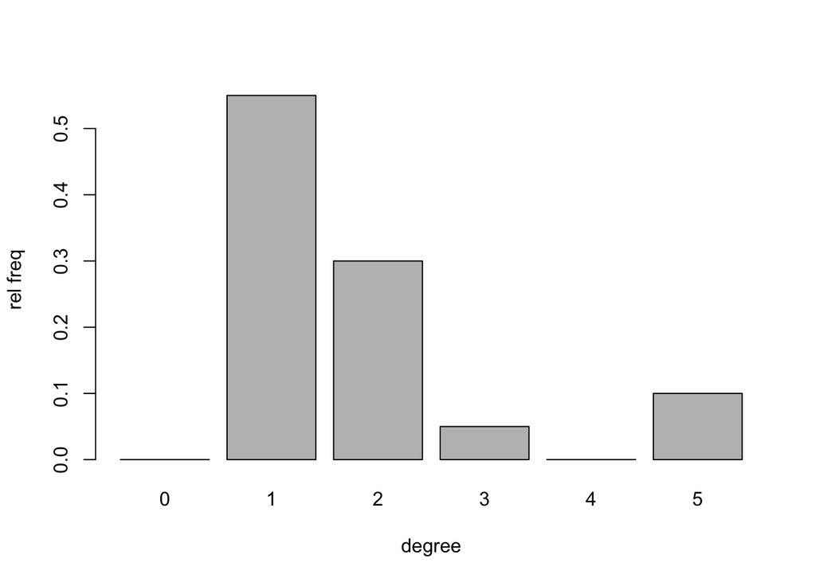

```r
dd <- degree_distribution(graph)

# the following two lines plot the degree distribution
x <- seq(0, length(dd)-1, by = 1)
barplot(dd, names = x, xlab = "degree", ylab = "rel freq")
```

## Write out an {igraph} data to a file…

```r
# in .csv format
write_csv(as_long_data_frame(graph), file = "~/Desktop/got.csv")

# in .graphml format
write_graph(graph, file = "~/Desktop/got.graphml", format = c("graphml"))
```

# Other cool things to explore

## Plot an {igraph} object with {visNetwork} directly

```r
visIgraph(graph)
```

[interactive chart not shown]

```r
# here, graph is an {igraph} object, and
# visIgraph() is a function from {visNetwork}
```

## Convert an {igraph} object to a {visNetwork} object

```r
graph <- toVisNetworkData(graph, idToLabel = TRUE)
```

## {visNetwork} options

Below are some examples of interesting {visNetwork} options for tweaking graph layouts (e.g., by editing the *physics* of layout positioning) and for interacting with a graph…

```r
visNetwork(graph$nodes, graph$edges) %>%
  visPhysics(
    solver = "forceAtlas2Based",
    forceAtlas2Based = list(gravitationalConstant = -30)
    )
```

[interactive chart not shown]

```r
visNetwork(graph$nodes, graph$edges) %>%
  visPhysics(solver = "repulsion")
```

[interactive chart not shown]

```r
visNetwork(graph$nodes, graph$edges) %>%
  visOptions(
    highlightNearest = list(
      enabled = TRUE,
      hover = TRUE,
      degree = 1,
      hideColor = "rgba(0,0,0,0.05)")
    ) %>%
  visEdges(color = list(inherit = "to"))
```

[interactive chart not shown]

```r
visNetwork(graph$nodes, graph$edges) %>%
  visOptions(manipulation = TRUE) %>%
  visLayout(randomSeed = 123)
```

[interactive chart not shown]

# Visualizing and working with other datasets from the package {igraphdata}

```r
library(igraphdata)
data("foodwebs") # list containing multiple {igraph} objects
graph <- foodwebs$Narragan
visIgraph(graph)
```

[interactive chart not shown]

```r
data("USairports") # a single {igraph} object
graph <- USairports
visIgraph(USairports)
```

[interactive chart not shown]

### Questions

- Calculate the mean degree and plot the degree distribution for each of the new networks graphed above

# Centrality Measures

Let’s go back to the Game of Thrones graph…

```r
graph <- graph_from_data_frame(
  d = edges,
  vertices = vertices,
  directed = FALSE)

visIgraph(graph)
```

[interactive chart not shown]

```r
betweenness( # with edges weighted...
  graph,
  directed = FALSE
)
```

```
        Arya-Stark         Bran-Stark              Bronn      Catelyn-Stark
                 0                  6                  0                  0
  Cersei-Lannister Daenerys-Targaryen       Eddard-Stark       Jeor-Mormont
                 4                  1                  9                  0
 Joffrey-Baratheon           Jon-Snow        Sansa-Stark              Luwin
                 0                 19                  1                  0
        Robb-Stark   Tyrion-Lannister   Robert-Baratheon              Drogo
                 0                  6                  0                  0
     Jorah-Mormont      Petyr-Baelish              Varys      Samwell-Tarly
                 0                  0                  0                  0
```

```r
E(graph)$weight <- 1

betweenness( # with edges set to uniform weight
  graph,
  directed = FALSE
)
```

```
        Arya-Stark         Bran-Stark              Bronn      Catelyn-Stark
                 0                  6                  0                  0
  Cersei-Lannister Daenerys-Targaryen       Eddard-Stark       Jeor-Mormont
                 0                  1                  9                  0
 Joffrey-Baratheon           Jon-Snow        Sansa-Stark              Luwin
                 0                 17                  1                  0
        Robb-Stark   Tyrion-Lannister   Robert-Baratheon              Drogo
                 0                  6                  0                  0
     Jorah-Mormont      Petyr-Baelish              Varys      Samwell-Tarly
                 0                  0                  0                  0
```